# Question 5

Dorothy Chepkoech

2025-11-17

[output not shown]

```
## Linear mixed model fit by REML. t-tests use Satterthwaite's method [
## lmerModLmerTest]
## Formula: bprs ~ time + sex + age + bmi + job + adl + wzc + cdrsb0 + abpet0 +
##     time:cdrsb0 + 1 + (time | patid) + (1 | trial)
##    Data: alzheimer_long
##
## REML criterion at convergence: 27123
##
## Scaled residuals:
##     Min      1Q  Median      3Q     Max
## -3.6325 -0.5997 -0.0071  0.5905  3.3187
##
## Random effects:
##  Groups   Name        Variance Std.Dev. Corr
##  patid    (Intercept) 0.8076   0.8987
##           time        0.6863   0.8284   -0.61
##  trial    (Intercept) 7.9799   2.8249
##  Residual             2.6980   1.6426
## Number of obs: 6220, groups:  patid, 1253; trial, 25
##
## Fixed effects:
##                   Estimate Std. Error         df t value Pr(>|t|)
## (Intercept)     -6.026e+01  4.173e+00  9.539e+02 -14.441  < 2e-16 ***
## time             7.220e+00  4.026e-02  9.957e+02 179.318  < 2e-16 ***
## sexFemale       -1.632e-01  8.797e-02  1.170e+03  -1.856   0.0637 .
## age              1.695e+00  4.060e-02  1.056e+03  41.755  < 2e-16 ***
## bmi              1.782e-01  2.731e-02  1.203e+03   6.527 9.88e-11 ***
## jobPaid Job     -5.138e+00  8.044e-01  1.057e+03  -6.387 2.53e-10 ***
## adl              6.520e-02  1.178e-01  1.053e+03   0.553   0.5801
## wzcNursing Home  1.910e+00  9.927e-02  1.261e+03  19.246  < 2e-16 ***
## cdrsb0           1.995e-03  7.604e-03  1.082e+03   0.262   0.7931
## abpet0           4.872e-02  1.584e-01  1.209e+03   0.308   0.7584
## time:cdrsb0     -2.177e-02  4.149e-03  9.707e+02  -5.248 1.89e-07 ***
## ---
## Signif. codes:  0 '***' 0.001 '**' 0.01 '*' 0.05 '.' 0.1 ' ' 1
##
## Correlation of Fixed Effects:
##             (Intr) time   sexFml age    bmi    jbPdJb adl    wzcNrH cdrsb0
## time        -0.009
## sexFemale    0.022 -0.005
## age         -0.974 -0.003 -0.039
## bmi         -0.773 -0.004  0.001  0.688
## jobPaid Job  0.955 -0.001  0.025 -0.948 -0.697
## adl         -0.975  0.003  0.001  0.970  0.708 -0.983
## wzcNursngHm  0.046 -0.015  0.034 -0.058  0.001  0.036 -0.006
## cdrsb0      -0.017  0.444  0.045  0.007 -0.014 -0.013  0.011  0.016
## abpet0       0.037 -0.004 -0.087 -0.161 -0.027  0.004 -0.018 -0.163 -0.003
## time:cdrsb0  0.006 -0.677  0.005  0.002  0.003  0.000  0.001  0.000 -0.650
##             abpet0
## time
## sexFemale
## age
## bmi
## jobPaid Job
## adl
## wzcNursngHm
## cdrsb0
## abpet0
## time:cdrsb0  0.002
```

```
## Generalized least squares fit by maximum likelihood
##   Model: fm_adj
##   Data: alzheimer_long
##        AIC     BIC    logLik
##   27309.62 27572.3 -13615.81
##
## Correlation Structure: General
##  Formula: ~time | patid
##  Parameter estimate(s):
##  Correlation:
##   1     2     3     4     5     6
## 2 0.316
## 3 0.330 0.500
## 4 0.275 0.533 0.684
## 5 0.258 0.541 0.706 0.786
## 6 0.212 0.526 0.694 0.810 0.857
## 7 0.243 0.536 0.719 0.824 0.878 0.900
## Variance function:
##  Structure: Different standard deviations per stratum
##  Formula: ~1 | time
##  Parameter estimates:
##        1        2        3        4        5        6        7
## 1.000000 1.146401 1.426037 1.733362 2.111631 2.485352 2.862663
##
## Coefficients:
##                      Value Std.Error   t-value p-value
## (Intercept)     -130.83407 1.3723262 -95.33744  0.0000
## time               7.22014 0.0402478 179.39190  0.0000
## sexFemale         -0.27906 0.0980071  -2.84732  0.0044
## age                2.37856 0.0151867 156.62167  0.0000
## bmi                0.50693 0.0225342  22.49618  0.0000
## jobPaid Job      -18.58757 0.3187472 -58.31445  0.0000
## adl                2.06497 0.0406792  50.76244  0.0000
## wzcNursing Home    1.80886 0.1102217  16.41113  0.0000
## cdrsb0             0.00275 0.0081670   0.33655  0.7365
## abpet0             0.27064 0.1728257   1.56599  0.1174
## time:cdrsb0       -0.02193 0.0041482  -5.28667  0.0000
##
##  Correlation:
##                 (Intr) time   sexFml age    bmi    jbPdJb adl    wzcNrH cdrsb0
```

[output cut: 13 more lines]

```
## age
## bmi
## jobPaid Job
## adl
## wzcNursing Home
## cdrsb0
## abpet0
## time:cdrsb0      0.001
##
## Standardized residuals:
##        Min         Q1        Med         Q3        Max
## -3.5898411 -0.6787763  0.0148935  0.6561981  3.8070698
##
## Residual standard error: 1.930738
## Degrees of freedom: 6220 total; 6209 residual
```

####Step 2:Compare with the multivariate (GLS) model

```
## # A tibble: 11 × 3
##    term            estimate_gls estimate_lmer
##    <chr>                  <dbl>         <dbl>
##  1 (Intercept)       -131.          -60.3
##  2 time                 7.22          7.22
##  3 sexFemale           -0.279        -0.163
##  4 age                  2.38          1.70
##  5 bmi                  0.507         0.178
##  6 jobPaid Job        -18.6          -5.14
##  7 adl                  2.06          0.0652
##  8 wzcNursing Home      1.81          1.91
##  9 cdrsb0               0.00275       0.00199
## 10 abpet0               0.271         0.0487
## 11 time:cdrsb0         -0.0219       -0.0218
```

# Question 5

## Random Effects model

To understand how psychiatric symptoms evolve over time in Alzheimer’s disease, we developed a statistical model that accounts for repeated measurements in each patient. This model allows each patient to have their own starting level of symptoms and their own rate of change over time. The outcome of interest was the Brief Psychiatric Rating Scale (BPRS), measured annually over six years.

We build a random-effects model, compare it to the multivariate model used earlier, and evaluate how well it describes both population-level trends and patient-specific trajectories.

Here, We chose to fit linear mixed effects model which incorporates both population-averaged effects and patient-specific deviations.Because our data include multiple clinical sites, we also included a random intercept for trial, allowing for differences between centers

This choice was motivated by the structure of the data: repeated BPRS measurements for each patient over 6 years, with clear variability both in baseline symptom severity and rate of change between patients.A mixed model is appropriate here because it:

1. Explicitly accounts for correlation within patients (repeated measures from the same individual),
2. allows patient-specific trajectories (subject-specific intercepts and slopes),
3. uses all available data, including patients with incomplete follow-up.
4. and Adjusts the individual trajectories for baseline patient characteristics, improving precision.

We estimated the model using REML (Restricted Maximum Likelihood), which typically provides less biased variance estimates in mixed models, especially when the number of clusters (patients) is large and fixed effects are substantial.

The main assumptions are:

1. A linear relationship between time and BPRS (within the follow-up window),
2. Approximately normally distributed residuals and random effects,
3. Homogeneity of residual variance (after allowing for random effects),
4. And implicitly, that missing data (dropout) are at least missing at random (MAR) conditional on the covariates and random effects.

Advantages:

1. Provides both population-average effects and individual-level estimates (intercepts and slopes),
2. More efficient and less noisy than the two-stage approach,
3. Adjusts subject-specific trajectories for baseline characteristics (age, ADL, WZC, etc.),
4. Handles unbalanced data (different numbers and timings of visits).
5. Quantifies variability both within patients and between clinical sites.

Disadvantages / potential issues:

1. The model is more complex and harder to explain to non-statisticians,
2. It can be sensitive to model specification (e.g., choice of random-effects structure, linearity of time),

## The model fitted

For patient $i$ in trial $j$ at time point $t$, the linear mixed-effects model is:

$$\text{BPRS}_{ijt} =
(\beta_0 + b_{0i} + u_{0j})
+ (\beta_1 + b_{1i}) \cdot \text{time}_{ijt}
+ \beta_2 \text{sex}_i
+ \beta_3 \text{age}_i
+ \beta_4 \text{bmi}_i
+ \beta_5 \text{job}_i
+ \beta_6 \text{adl}_i
+ \beta_7 \text{wzc}_i
+ \beta_8 \text{cdrsb0}_i
+ \beta_{10} \text{abpet0}_i
+ \beta_{11} (\text{time}_{ijt} \times \text{cdrsb0}_i)
+ \epsilon_{ijt}.$$

### Where:

- $\beta$’s = population-level (fixed) effects
- $b_{0i}$ = patient-specific deviation in baseline symptom severity (random intercept)
- $b_{1i}$ = patient-specific deviation in rate of symptom change (random slope)
- $u_{0j}$ = trial-specific deviation in baseline symptom severity (random intercept for trial)
- $\epsilon_{ijt}$ = residual error

## Random effects

### Patient-specific random effects

$$\begin{pmatrix}
b_{0i} \\
b_{1i}
\end{pmatrix}
\sim
N\!\left(
\begin{pmatrix}
0 \\
0
\end{pmatrix},
\begin{pmatrix}
\sigma_{b0}^2 & \sigma_{b0,b1} \\
\sigma_{b0,b1} & \sigma_{b1}^2
\end{pmatrix}
\right).$$

### Trial-level random intercept

$$u_{0j} \sim N(0, \sigma_{u0}^2).$$

### Residual error

$$\epsilon_{ijt} \sim N(0, \sigma^2).$$

This model allows patients to vary in both their **starting level of psychiatric symptoms** and their **rate of symptom progression**, while also accounting for **differences between clinical trials** through the trial-specific random intercept.

## Results

The linear mixed-effects model showed a significant yearly increase in psychiatric symptom severity, with BPRS scores rising by 7.22 points per year (p < 0.001). Several baseline characteristics were significantly associated with overall BPRS levels, including age (+1.70, p < 0.001), BMI (+0.18, p < 0.001), paid employment (–5.14, p < 0.001), and nursing home residence (+1.91, p < 0.001). Sex showed a borderline effect, with females scoring slightly lower (–0.16, p = 0.064), while ADL score, baseline CDR-SB, and amyloid PET were not significant predictors. The interaction between baseline CDR-SB and time was significant (–0.022, p < 0.001). The random-effects structure indicated substantial patient-level variability, with a standard deviation of 0.90 for baseline symptom levels and 0.83 for rates of symptom change, and a negative intercept–slope correlation (–0.61). Trial-level variability was also present, with a trial-specific intercept standard deviation of 2.83. Overall, the model included 6,220 observations from 1,253 patients across 25 clinical trials.

```
## # A tibble: 11 × 5
##    term             estimate std.error statistic   p.value
##    <chr>               <dbl>     <dbl>     <dbl>     <dbl>
##  1 (Intercept)     -60.3       4.17      -14.4   6.74e- 43
##  2 time              7.22      0.0403    179.    0
##  3 sexFemale        -0.163     0.0880     -1.86  6.37e-  2
##  4 age               1.70      0.0406     41.8   8.62e-226
##  5 bmi               0.178     0.0273      6.53  9.88e- 11
##  6 jobPaid Job      -5.14      0.804      -6.39  2.53e- 10
##  7 adl               0.0652    0.118       0.553 5.80e-  1
##  8 wzcNursing Home   1.91      0.0993     19.2   1.43e- 72
##  9 cdrsb0            0.00199   0.00760     0.262 7.93e-  1
## 10 abpet0            0.0487    0.158       0.308 7.58e-  1
## 11 time:cdrsb0      -0.0218    0.00415    -5.25  1.89e-  7
```

####Diagnostics: Evaluating Model Appropriateness To ensure that the linear mixed-effects model (which estimates both the average progression of BPRS over time and patient-specific patterns) is statistically reliable, several diagnostic checks were performed. These checks help determine whether the model’s assumptions are met, and whether the results can be trusted.

#####3.1 Residual Diagnostics

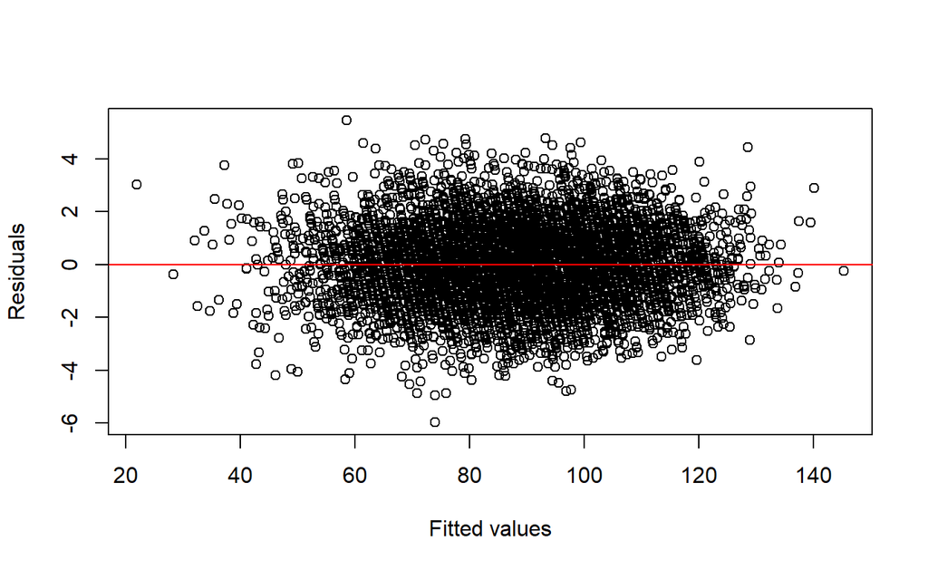

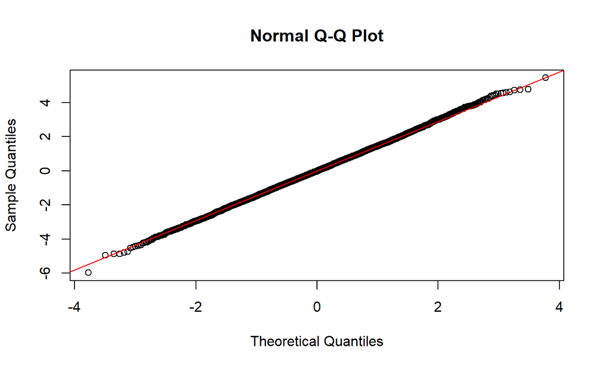

### Figure 1. Normality of Residuals (Q–Q Plot)

The Q–Q plot compares the distribution of the model residuals (errors) to what would be expected if they followed a normal distribution, which is an underlying assumption of linear mixed-effects models.The residuals aligned closely with the expected diagonal pattern, showing only small deviations at the tails.The assumption of normally distributed residuals is largely satisfied. This supports the reliability of the estimated effects.

### Figure 2. Residuals vs. Fitted Values Plot

This plot assesses whether residuals are randomly distributed around zero, which reflects the assumption of constant variability (“homoscedasticity”).Residuals are spread evenly around zero with no funnel shape or curvature. This indicates Variance is stable across time, The model does not systematically under- or over-predict symptoms and The linearity assumption is appropriate. The model fits the data well and the variability is appropriately captured.

### Figure 3. Distribution of Patient-Specific Intercepts and Slopes

Overall, All diagnostic checks support the validity of the linear mixed-effects model:The residuals behave well (normal distribution and constant variance), The model captures both average disease progression and patient-specific trajectories, The variability across patients justifies including both random intercepts and slopes and The model provides more precise estimates than the two-stage approach and is more statistically efficient.

###Random effects (intercept & slope)

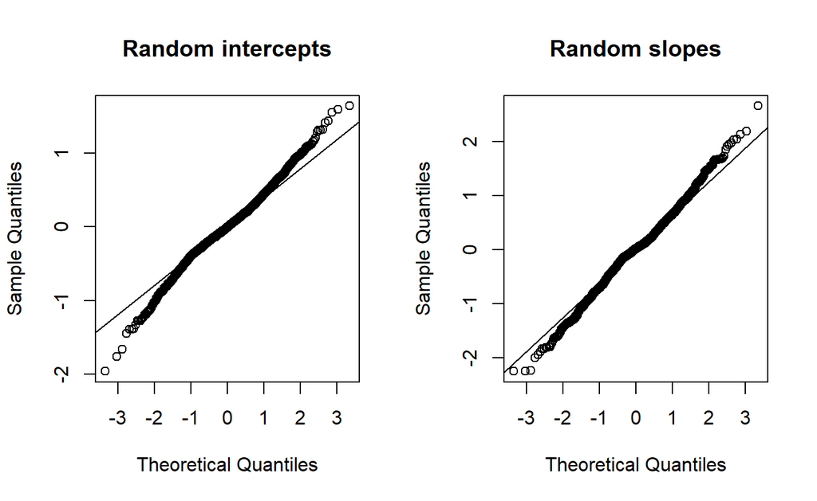

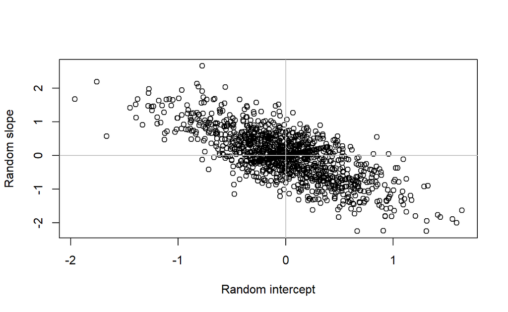

[figure not shown]

```
##   patid intercept_mixed slope_mixed  sexFemale     age       bmi jobPaid Job
## 1 10001       -60.44852    6.684441 -0.1632427 1.69542 0.1782479    -5.13797
## 2 10002       -60.30085    6.872080 -0.1632427 1.69542 0.1782479    -5.13797
## 3 10003       -60.45621    7.698563 -0.1632427 1.69542 0.1782479    -5.13797
## 4 10004       -60.75190    8.133365 -0.1632427 1.69542 0.1782479    -5.13797
## 5 10005       -60.12537    6.535762 -0.1632427 1.69542 0.1782479    -5.13797
## 6 10006       -60.43627    7.549847 -0.1632427 1.69542 0.1782479    -5.13797
##          adl wzcNursing Home    cdrsb0     abpet0 time:cdrsb0
## 1 0.06520149        1.910472 0.0019945 0.04872337 -0.02177329
## 2 0.06520149        1.910472 0.0019945 0.04872337 -0.02177329
## 3 0.06520149        1.910472 0.0019945 0.04872337 -0.02177329
## 4 0.06520149        1.910472 0.0019945 0.04872337 -0.02177329
## 5 0.06520149        1.910472 0.0019945 0.04872337 -0.02177329
## 6 0.06520149        1.910472 0.0019945 0.04872337 -0.02177329
```

### Comparison With the Two-Stage Analysis

To better understand how each patient’s symptoms (BPRS scores) change over time, we estimated individual starting points (intercepts) and rates of change (slopes) in two different ways: 1) Two-stage approach , running a separate simple linear regression for each patient.(Question 4) 2) Random-effects mixed model – using all patients’ data together while allowing each patient to have their own intercept and slope.

We then compared the two methods to see whether the more advanced mixed model provides meaningful improvement.

#####Step 3.4 Merge with two-stage results and compare

```
## [1] 0.07488048
```

```
## [1] 0.7625341
```

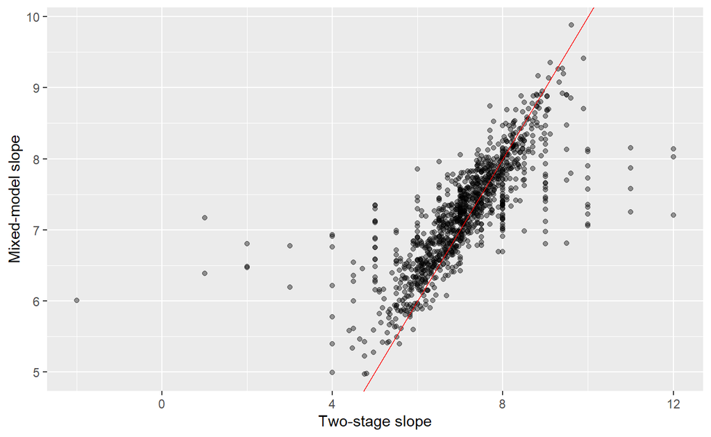

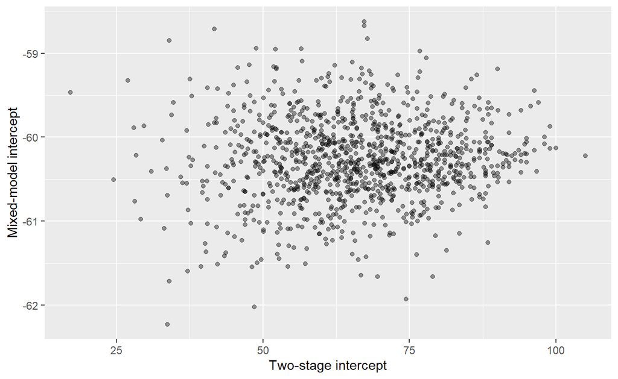

#### Why are the mixed-model estimates still preferred?

1. It uses all available data efficiently

The mixed model:Handles patients with different numbers of visits, Corrects for measurement error and Shrinks extreme individual estimates toward the population average (reducing noise)

2)It adjusts for all predictors The two-stage approach cannot adjust for these characteristics when estimating patient-level slopes. The mixed model does this automatically. 3) It accounts for correlation within patients Longitudinal data contain repeated measures from the same person. The mixed model captures the dependency between these repeated measurements; the two-stage method does not.

###Reflection on parameterization

The chosen parameterization had two main components:

symptom severity depends on demographic, functional, and disease severity markers at baseline, and

cognitive status modifies the trajectory of psychiatric symptoms (time × CDRSB0).

A key simplification is assuming a linear trajectory in time; in reality, progression could be non-linear (e.g., faster early or late). If time effects are non-linear, a model with splines or time as a factor could fit better, but at the cost of interpretability and more parameters.

Covariance structure (random effects): We chose random intercepts and random slopes for time at the patient level, with an unstructured 2×2 covariance matrix. This is a very interpretable parameterization: one parameter for variability in baseline severity, one for variability in slope, and one for their correlation. Compared with fully unstructured residual covariance (as in the GLS model), this is more parsimonious and more directly linked to clinical ideas like “patients start differently” and “patients change at different speeds”.

The model therefore strikes a balance between flexibility (allowing heterogeneity in trajectories) and interpretability (simple linear time, clinically meaningful random effects). In future, we might consider testing alternative parameterizations (e.g., non-linear time, random effects on additional covariates) but for this dataset, the chosen structure appears adequate and clinically interpretable.

### Clinician Summary Report

To better understand how psychiatric symptoms change over time in patients with Alzheimer’s disease, we used a modeling approach that allows each patient to have their own starting symptom severity and their own pattern of progression. This method, called a mixed-effects model, is well suited for long-term follow-up studies where individuals may be measured many times and may not all remain in the study for the same duration.

The analysis showed that psychiatric symptoms worsen steadily over time, with patients on average increasing by about 7 BPRS points per year. However, not all patients start at the same level or decline at the same speed. Our model captured this variation and revealed important patient characteristics that help explain these differences.

Overall, this approach provides a detailed picture of how psychiatric symptoms evolve in Alzheimer’s disease. It shows which baseline factors are linked with faster decline, and it gives individualized estimates of symptom progression. These findings can help to better understand patient variability, identify patients who may be at higher risk for rapid deterioration, and guide monitoring and care strategies over the course of the disease.

### Recommendations for future similar experiments

From a modeling and design perspective, several recommendations emerge:

1. systematic recording of dropout reasons: Since dropout can bias longitudinal analyses, future studies should routinely document why patients leave the study (death, institutionalization, refusal, health decline). This would allow sensitivity analyses under different missing-data assumptions (MAR vs MNAR).
2. Richer covariate information on treatment and care: Including medication use (e.g., antipsychotics, antidepressants), psychosocial interventions, caregiver burden, and comorbidities might help explain additional between-patient variation and could identify modifiable risk factors for rapid deterioration.

3)Parallel assessment of multiple outcome domains Since cognition, function, and psychiatric symptoms are closely related in Alzheimer’s disease, future experiments could be designed to jointly model these domains rather than analyzing each in isolation. This would provide a more integrated picture of disease progression and may better inform clinical decision-making.